# Data finding

The data from https://data.world/data-society/airplane-crashes is seems to be not full and up-to-date.

I decided to parse data from https://aviation-safety.net/database/databases.php. It is a source of previous one, but it is supporting and up-to-date.

I used parser, which is included in project directory.

## Uploading data

Data fields in parsed data:

- Date: Date of accident, in the format - January 01, 2001
- Time: Local time, in 24 hr. format unless otherwise specified
- location: location of incedent
- Airline/Op: Airline or operator of the aircraft
- Flight #: Flight number assigned by the aircraft operator
- Route: Complete or partial route flown prior to the accident
- AC Type: Aircraft type
- Reg: ICAO registration of the aircraft
- cn / ln: Construction or serial number / Line or fuselage number
- Aboard: Total aboard (passengers / crew)
- Fatalities: Total fatalities aboard (passengers / crew)
- Ground: Total killed on the ground
- Summary: Brief description of the accident and cause if known

Data fields in report data:

- year
- fatal accidents per mln flights

```python
import pandas as pd
# import libraries
import altair as alt
import pandas as pd
import numpy as np

# it just needs to be here so we can work with big files
alt.data_transformers.enable('default', max_rows=None)
# alt.renderers.enable('notebook')

df = pd.read_csv('https://github.com/trokhymovych/data-viz-UCU2019/raw/master/Final_project/data/planecrashinfo_scraping-master/planecrashinfo_20200110102045.csv')
df_report = pd.read_csv('https://github.com/trokhymovych/data-viz-UCU2019/raw/master/Final_project/data/f.csv', sep = ';')
df_report.fillna(method='ffill', inplace=True)
```

```python
df.tail(3)
```

|  | date | time | location | operator | flight_no | route | ac_type | registration | cn_ln | all_aboard | passengers_aboard | crew_aboard | all_fatalities | passenger_fatalities | crew_fatalities | ground | summary |
| --- | --- | --- | --- | --- | --- | --- | --- | --- | --- | --- | --- | --- | --- | --- | --- | --- | --- |
| 4971 | November 24, 2019 | 0915 | Goma, Democratic Republic of Congo | Busy Bee Congo | ? | Goma - Beni | Dornier 228-201 | 9S-GNH | 8030 | 19 | 17 | 2 | 19 | 17 | 2 | 7 | The passenger plane crashed about a minute aft... |
| 4972 | December 27, 2019 | 0722 | Almaty, Kazakhstan | Bek Air | Z92100 | Almaty - Nursultan Nazabavev | Fokker 100 | UP-F100 | 11496 | 98 | 95 | 3 | 12 | ? | ? | 0 | While taking off, the tail of the plane struck... |
| 4973 | January 08, 2020 | 0618 | Near Shahriah, Iran | Ukraine International Airlines | PS752 | Tehran - Kiev | Boeing 737-8KV WL | UR-PSR | 38124/5977 | 176 | 167 | 9 | 176 | 167 | 9 | 0 | The plane took off from Tehran International A... |

```python
df_report.head(2)
```

|  | World air traffic (departures) | 1 accident \nper x flights | fatal accidents \nper mln flights | Year | Unnamed: 4 | Unnamed: 5 | Unnamed: 6 |
| --- | --- | --- | --- | --- | --- | --- | --- |
| 0 | 9448300.0 | 157472.0 | 6.35 | 1970 | NaN | NaN | NaN |
| 1 | 9504500.0 | 202223.0 | 4.95 | 1971 | NaN | NaN | NaN |

```python
df.describe(include='all')
```

|  | date | time | location | operator | flight_no | route | ac_type | registration | cn_ln | all_aboard | passengers_aboard | crew_aboard | all_fatalities | passenger_fatalities | crew_fatalities | ground | summary |
| --- | --- | --- | --- | --- | --- | --- | --- | --- | --- | --- | --- | --- | --- | --- | --- | --- | --- |
| count | 4974 | 4974 | 4974 | 4974 | 4974 | 4974 | 4974 | 4974 | 4974 | 4974 | 4974 | 4974 | 4974 | 4974 | 4974 | 4974 | 4974 |
| unique | 4546 | 1251 | 4097 | 2245 | 887 | 3805 | 2444 | 4668 | 3875 | 244 | 233 | 32 | 200 | 191 | 29 | 52 | 4816 |
| top | September 11, 2001 | ? | Moscow, Russia | Aeroflot | ? | ? | Douglas DC-3 | ? | ? | 3 | 0 | 3 | 1 | 0 | 2 | 0 | ? |
| freq | 4 | 1512 | 17 | 255 | 3656 | 774 | 333 | 273 | 668 | 278 | 855 | 947 | 383 | 1024 | 885 | 4690 | 63 |

# Preprocessing data

```python
# clean up all results with no information about passangers and fatalities (drop about 20 records):
df = df[df.all_aboard!='?']
df = df[df.all_fatalities!='?']
```

#### Getting longtitude and latitude from location string using Google Geocoding API

```python
# import googlemaps
# import numpy as np
# API_KEY = 'XXXXXXXXXXX'
# gmaps = googlemaps.Client(key=API_KEY)

# def get_coordinates(address):
#     geocode_result = gmaps.geocode(str(address))
#     if len(geocode_result) > 0:
#         return list(geocode_result[0]['geometry']['location'].values())
#     else:
#         return [np.NaN, np.NaN]
```

```python
# coordinates = df['location'].apply(lambda x: pd.Series(get_coordinates(x), index=['LATITUDE', 'LONGITUDE']))
# df2 = pd.concat([df[:], coordinates[:]], axis="columns")
```

```python
def del_MILITARY(strr):
  return strr.replace('Military - ', '')

# df2.to_csv('df_with_location.csv', index = False)
df2 = pd.read_csv('https://github.com/trokhymovych/data-viz-UCU2019/raw/master/Final_project/data/df_with_location.csv')
df2.date = pd.to_datetime(df2.date)
df2 = df2[df2.date>pd.datetime(year = 1970, month = 1, day = 1)]
df2 = df2[df2.date!=pd.datetime(year = 1979, month = 11, day = 28)] # drop some outlier in location
df2['Year'] = df2['date'].dt.year #for filter purposes
df2['un'] = df2.index #for filter purposes as unique identifier
df2['operator_to_plot'] = df2.operator.apply(del_MILITARY)
```

## Dynamic of number of crashes in time

## Crash trend

Here is three plots are combined into a grid view to observe the trend in the fatal flights ratio over the years and also total numbers of accidents by the months and day of the week in particular. A trend line of crashes ratio per year shows that the probability of accident in the air is decreasing from year to year.

The monthwise analysis just gives a confirmation that crashes occur irrespective of the month and day of the week. That means, the time of the year is not significant influencing parameter.

```python
# configurations
Blue = "#69b8d6"
Red = '#d53e4f'
Gray = '#5D646F'
Grid = '#5D646F'

title_color = Gray
text_color = Gray
text_size = 14
title_size = 18
background = '#F3F7F7'

font = 'Helvetica Neue'

# customizing main Axes
axisX = alt.Axis(gridDash = [0,2,0],
                 values = [1970,1980,1990,2000,2010,2019],
                 grid=True,
                 domain=False,
                 tickDash=[0,2,0],
                 tickColor = 'lightgray',
                 labelAngle =0,
                 labelColor = Gray,
                 labelFont = font,
                 labelFontSize = text_size,
                 labelPadding = 15,
                 titleFontSize = title_size,
                 titleFontWeight = 300,
                 titleColor = Gray,
                 titlePadding = 10,
                 titleFont = font,
                 titleAngle = 0,
                 titleY =  -5,
                 titleX = 770)

axisY = alt.Axis(values = [i for i in range(1, 7)],
                 gridDash = [0,2,0], grid=True,
                 domain=False,
                 ticks=False,
                 labelAngle =0,
                 labelColor = Gray,
                 labelFontSize = text_size,
                 labelFont = font,
                 labelPadding = 7,
                 titleFontSize = title_size,
                 titleFontWeight = 300,
                 titleColor = Gray,
                 titlePadding = 10,
                 titleFont = font,
                 titleAngle = 0,
                 titleY =  -10,
                 titleX = 90)

# axes for text
ax2 = alt.Axis(grid=False, domain=False, ticks=False, labelColor="transparent")
```

```python
chart1 = alt.Chart(df_report, title = 'Dynamic of fatal flights rate').mark_line(opacity = 0.8).encode(
    x = alt.X('Year:N', title = 'year', axis = axisX),
    y = alt.Y('fatal accidents \nper mln flights:Q', title = 'Fatal accidents per million flights', axis = axisY), #title = 'Number of reviews'
    color = alt.value(Red),
    tooltip = alt.Tooltip(['fatal accidents \nper mln flights', 'Year'])
).properties(width=800, height=250)

# footer
text_df_footer = pd.DataFrame({'text':['Data: the Aviation Safety Network database (http://aviation-safety.net)']})
footer = alt.Chart(text_df_footer).mark_text(fontSize=text_size, font=font, color = Gray, dx = 800/2, align = 'right').encode(
    text='text').properties(width=800, height=20)
```

```python
axisX2 = alt.Axis(gridDash = [0,2,0],
                 grid=False,
                 domain=False,
                 labels = False,
                 ticks = False,
                 titleFontSize = title_size,
                 titleFontWeight = 300,
                 titleColor = Gray,
                 titlePadding = 10,
                 titleFont = font,
                 titleAngle = 0)

axisY2 = alt.Axis(
                 gridDash = [0,2,0], grid=True,
                 domain=False,
                 ticks=False,
                 labelAngle = 0,
                 labelColor = Gray,
                 labelFontSize = text_size,
                 labelFont = font,
                 labelPadding = 7,
                 titleFontSize = title_size,
                 titleFontWeight = 300,
                 titleColor = Gray,
                 titlePadding = 10,
                 titleFont = font,
                 titleAngle = 0, titleY = -10, titleX = 130)



d = df2.groupby(df2['date'].dt.strftime('%B'))[['location']].count()
new_month = ['January', 'February', 'March', 'April', 'May', 'June', 'July', 'August', 'September', 'October', 'November', 'December']
d['month'] = d.index

# total number of crashes per month
hist1 = alt.Chart(d).mark_bar(
    cornerRadiusTopLeft=3,
    cornerRadiusTopRight=3
).encode(
    x=alt.X('month:O', title = None, scale=alt.Scale(zero=False), sort = new_month, axis = axisX2),
    y=alt.Y('location:Q', title = 'Total number of accidents by month', axis = axisY2),
    color = alt.value(Blue)
).properties(width=370, height=170)

text = hist1.mark_text(
    align='left',
    baseline='middle',
    font = font,
    color = background,
    angle = 360 - 90,
    fontSize=16
).encode(
    y = alt.value(160),
    text=alt.Text('month'),
    color = alt.value(background)
)
hist1 = hist1+text
```

```python
axisY2 = alt.Axis(gridDash = [0,2,0], grid=True,
                 domain=False,
                 ticks=False,
                 labelAngle = 0,
                 labelColor = Gray,
                 labelFontSize = 13,
                 labelFont = font,
                 labelPadding = 7,
                 titleFontSize = 18,
                 titleFontWeight = 300,
                 titleColor = Gray,
                 titlePadding = 10,
                 titleFont = font,
                 titleAngle = 0, titleY = -10, titleX = 150)

d = df2.groupby(df2['date'].dt.strftime('%A'))[['location']].count()
new_day = ['Monday', 'Tuesday', 'Wednesday', 'Thursday', 'Friday', 'Saturday', 'Sunday']
d['month'] = d.index

# total number of crashes per month
hist2 = alt.Chart(d).mark_bar(
    cornerRadiusTopLeft=3,
    cornerRadiusTopRight=3
).encode(
    x=alt.X('month:O', title = None, scale=alt.Scale(zero=False), sort = new_day, axis = axisX2),
    y=alt.Y('location:Q', title = 'Total number of accidents by day of week', axis = axisY2),
    color = alt.value(Blue)
).properties(width=370, height=170)

text = hist2.mark_text(
    align='left',
    baseline='middle',
    font = font,
    color = background,
    angle = 360 - 90,
    fontSize=16
).encode(
    y = alt.value(160),
    text=alt.Text('month'),
    color = alt.value(background)
)
hist2 = hist2+text
```

```python
(chart1&(hist1|hist2)&footer).configure(background=background,  padding={"left": 40, "top": 30, "right": 40, "bottom": 30}
).configure_view(
    stroke='transparent'
).configure_axis(
    domainWidth=0.8
).configure_title(fontSize=30,
                  color = Gray,
                  font=font,
                  fontWeight = 600,
                  anchor = 'start'
)
```

[interactive chart not shown]

**Here is three plots are combined into a grid view to observe the trend in the fatal flights ratio over the years and also total numbers of accidents by the months and day of the week in particular. A trend line of crashes ratio per year shows that the probability of accident in the air is decreasing from year to year.**

**The monthwise analysis just gives a confirmation that crashes occur irrespective of the month and day of the week. That means, the time of the year is not significant influencing parameter.**

# Which airlines are the most dangerous?

To understand which operators caused more crashes the data is grouped by the operator and arranged in a descending format of the frequency. The graph has been plotted to observe the top 10 operators that caused the aircrash.

```python
def del_MILITARY(strr):
  return strr.replace('Military - ', '')

# data aggregation
Temp = df2.copy()
Temp['isMilitary'] = Temp.operator.str.contains('Military')
Temp = Temp.groupby('isMilitary')[['isMilitary']].count()
Temp.index = ['Civil', 'Military']
Temp['type'] = Temp.index
Temp['isMilitary_b'] = [False, True]

domain = ['Civil', 'Military']
range_ = [Blue, Red]

# Number of NaNs in specific fields

df2.loc[df2.operator == 'Military - U.S. Air Force', 'operator'] = 'Military - U.S. Army'
grouping_all = df2.groupby('operator').count().sort_values('date', ascending = False)[['date']]
grouping_all['operator'] = grouping_all.index
grouping_all['operator_to_plot'] = grouping_all.operator.apply(del_MILITARY)
grouping_all['isMilitary_b'] = grouping_all.operator.str.contains('Military')
grouping_all['Total number of crashes'] = grouping_all['date']

# making interactive legend
selection = alt.selection_single(fields=['isMilitary_b'])

hist2 = alt.Chart(Temp, title = alt.Text(text = 'Total amount', font = font, fontSize = text_size, color = Gray, fontWeight = 600, align = 'left', dx = -10)
).mark_bar().encode(
    y=alt.Y('isMilitary:Q', title = None, axis = ax2),
    color = alt.Color('type', scale=alt.Scale(domain=domain, range=range_), legend = None),
    opacity = alt.condition(selection, alt.value(0.9), alt.value(0.15))
).properties(height=280)

# annotations to the legend
text = hist2.mark_text(
    align='left',
    baseline='middle',
    font = font,
    color = Gray,
    fontSize=text_size,
    dx = 20, dy = 30
).encode(
    text=alt.Text('isMilitary'),
    color = alt.value( Gray)
).properties(height=280)

text2 = hist2.mark_text(
    align='left',
    baseline='middle',
    font = font,
    color = Gray,
    fontSize=text_size,
    dx = 20, dy = 10
).encode(
    text=alt.Text('type'),
    color = alt.value(Gray)
).properties(height=280)

legend = ((hist2+text+text2))

# axes
axisY = alt.Axis(grid=False,
                 domain=False,
                 ticks=False,
                 labels = False,
                 labelAngle = 0,
                 labelColor = text_color,
                 labelFontSize = text_size,
                 labelFontWeight = 400,
                 labelFont = font,
                 labelPadding = 5,
                 titleFontSize = 18,
                 titleFontWeight = 300,
                 titleColor = Gray,
                 titlePadding = 10,
                 titleFont = font,
                 titleAngle = 0, titleY = -10, titleX = 120)
# axes
axisX = alt.Axis(values = [20,40, 60,80, 100,120, 140],
                 grid=True,
                 gridDash = [0,2,0],
                 domain=False,
                 ticks=False,
                 labels = False,
                 titleColor = text_color,
                 titleFontSize = text_size,
                 titleFontWeight = 400,
                 titleFont = font,
                 labelPadding = 10,
                 titlePadding = 20
                 )

# make red
domain = list(grouping_all['operator'])
range_ = [Red if j else Blue for i,j in zip(range(len(domain)), list(grouping_all['isMilitary_b']))]

# # title
title_text = 'Top-10 airlines by number of crashes'
text_df_footer = pd.DataFrame({'text':[title_text]})
title = alt.Chart(text_df_footer).mark_text(fontWeight = 600, fontSize=30, font=font, color = Gray, align = 'center', dx = 10).encode(
    text='text').properties(width=500, height=40)

chart = alt.Chart(grouping_all).mark_bar(opacity = 0.9, cornerRadiusBottomRight=5, cornerRadiusTopRight=5).encode(
    y = alt.Y('operator:N', title = 'Total number of crashes by airline', sort = alt.Sort(field = 'date', order='descending'), axis = axisY),
    x = alt.X('date:Q', title = None, scale=alt.Scale(zero=False, domain = [0,145]), axis = axisX),
    color = alt.Color('operator', legend=None,
                      scale=alt.Scale(domain=domain, range=range_)),
    # tooltip = alt.Tooltip(['operator'])
).properties(width = 500, height = 300
).transform_filter(selection).transform_window(
    rank='row_number()',
    sort=[alt.SortField('date', order='descending')]
).transform_filter(
    alt.datum.rank < 11
)

text3 = chart.mark_text(
    align='left',
    baseline='middle',
    dx=3,  # Nudges text to right so it doesn't appear on top of the bar
    font = font,
    fontSize = text_size
).encode(
    text=alt.Text('date'),
    color = alt.value('#5D646F')
).properties(width = 500, height = 500)

text4 = chart.mark_text(
    align='right',
    baseline='middle',
    dx=-4,  # Nudges text to right so it doesn't appear on top of the bar
    font = font,
    fontSize = text_size
).encode(
    x = alt.value(0),
    text= alt.Text('operator_to_plot'),
    color = alt.value('#5D646F')
).properties(width = 500, height = 500)



# explanation
text_df_footer = pd.DataFrame({'text':['* The legend enables to filter only civil or military airlines']})
footer2 = alt.Chart(text_df_footer).mark_text(fontSize=text_size, font=font, color = Gray, dx = 800/2, align = 'right').encode(
    text='text').properties(width=500, height=20)
# footer
text_df_footer = pd.DataFrame({'text':['Data: the Aviation Safety Network database (http://aviation-safety.net)']})
footer = alt.Chart(text_df_footer).mark_text(fontSize=text_size, font=font, color = Gray, dx = 800/2, align = 'right').encode(
    text='text').properties(width=500, height=20)

foo = alt.vconcat(footer2, footer, spacing = 0)

main = alt.vconcat(title, ((chart+text3+text4)|legend.add_selection(selection)), spacing = 0)

hist2 = main&foo

hist2.configure(background=background,  padding={"left": 40, "top": 30, "right": 40, "bottom": 30}
).configure_view(
    stroke='transparent'
).configure_axis(
    domainWidth=0.8
)
```

[interactive chart not shown]

**To understand which operators caused more crashes the data is grouped by the operator and arranged in a descending format of the frequency. The graph has been plotted to observe the top 10 operators that caused the aircrash.**

**Aeroflot seems to be the most dangerous civil airline. Howewer, it is left in USSA.**.

# What are the most frequent/anomaly causes of crashes?

Description Here I have experimented with text mining in the summary column to form a word cloud that states the reasons for aircrash.

```python
!wget "https://www.cufonfonts.com/download/font/helvetica-neue-9"
```

```python
!unzip helvetica-neue-9
```

```python
!sudo mv HelveticaNeueBold.otf /usr/share/fonts/truetype/
```

```python
!pip install wordcloud
```

```python
## installing proper fonts
import matplotlib as mpl
import matplotlib.pyplot as plt
import matplotlib.font_manager as fm

# fetch the name of font that was installed
path = '/usr/share/fonts/truetype/HelveticaNeueBold.otf'
fontprop = fm.FontProperties(fname=path)
```

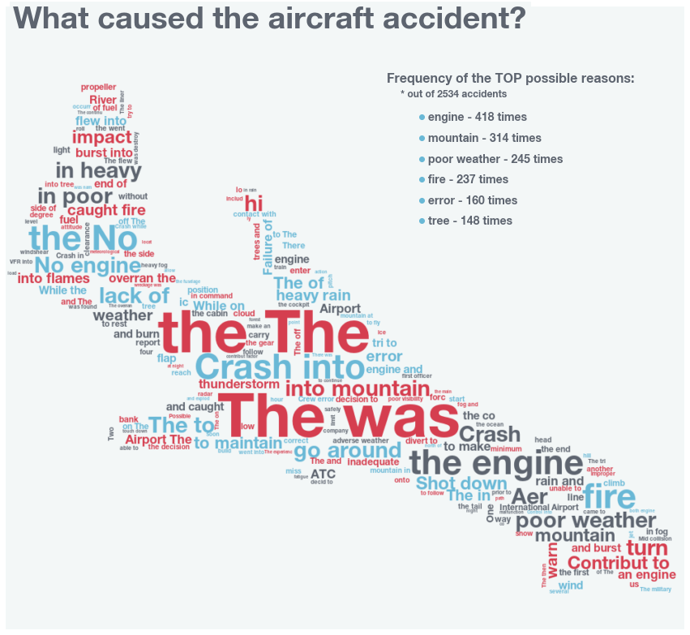

```python
from PIL import Image
import matplotlib.pyplot as plt
import matplotlib
import random
import requests
from io import BytesIO
from wordcloud import WordCloud, STOPWORDS
url = 'https://github.com/trokhymovych/data-viz-UCU2019/raw/master/Final_project/data/airplane-silhouette-vector-12.png'
response = requests.get(url)
plane_mask = np.array(Image.open(BytesIO(response.content)))
fig, ax = plt.subplots(nrows=1, ncols=1, figsize=(15,15))
text = str(list(df2.summary))

stopwords = set(STOPWORDS)
stopwords_list = ['aircraft', 'plane', 'crashed', 'flight', 'airport', 'two', 'aircraft', 'procee','result','kil',
                  'one', 'cargo', 'ground', 'due', 'takeoff', 'landing','attemping land', 'crew', 'passenger',
                  'approach', 'Caused', 'pilot', 'helicopter', 'runway', 'failure', 'terrain', 'return', 'follow'
                  'killed','airplane', 'three', 'captain', 'caused', 'Pilot', 'struck', 'descend', 'descent',
                  'control', 'instrument', 'taking', 'pilot', 'failed', 'right', 'left', 'shortly','dur','DUR',
                  'minute', 'en route', 'pilot', 'ft','attempting land', 'minutes', 'feet','lost','procedure','accident',
                  'flying','go around', 'sea', 'loss', 'short', 'hit', 'broke', 'stalled','system', 'crash','water',
                  'causing','near', 'land', 'area', 'condition', 'attempting','pilot','en route', 'mile', 'go around',
                  'resulted', 'field', 'aboard', 'took', 'reported', 'high', 'made', 'take', 'led', 'altitude','ing','ING',
                  'emergency', 'attempt', 'power', 'procedures', 'final', 'carrying', 'collided','second', 'km', 'problem', 'stall',
                  'time'] + ['pilot' for i in range(100)] + ['en route' for i in range(100)]+['airport' for i in range(40)]+['aer' for i in range(40)]+['AER' for i in range(40)]+['air' for i in range(40)]+['ed' for i in range(40)]


stopwords_list = stopwords_list+['spe' for i in range(40)]+['icing' for i in range(40)]+['improper' for i in range(40)]
for w in stopwords_list:
  stopwords.add(w)
  text = text.replace(w,'')

for i in range(120):
  stopwords.add(w)
  text = text.replace('weather conditions','poor weather')

# colors
def grey_color_func(word, font_size, position, orientation, random_state=None,
                    **kwargs):
    return np.random.choice([Blue,Red,Gray])

# font
font_path = '/usr/share/fonts/truetype/HelveticaNeueBold.otf'
fontprop1 = fm.FontProperties(fname=font_path, size = 38)
fontprop2 = fm.FontProperties(fname=font_path, size = title_size)
fontprop3 = fm.FontProperties(fname=font_path, size = text_size)
fontprop4 = fm.FontProperties(fname=font_path, size = text_size-2)

wc = WordCloud(max_words=200, mask=plane_mask, random_state=42, repeat = True,
              stopwords=stopwords,  font_step = 2, background_color = background, font_path=font_path)
wc.generate(text)

for w in stopwords_list:
  try:
    del wc.words_[w]
  except:
    1

plt.ylim((800,-100))
ax.imshow(wc.recolor(color_func=grey_color_func, random_state=3), interpolation='bilinear')
# ax.axis("off")
ax.set_facecolor(background)

# Additional styling
ax.axes.get_xaxis().set_ticks([])
ax.axes.get_yaxis().set_ticks([])
ax.spines['top'].set_visible(False)
ax.spines['right'].set_visible(False)
ax.spines['bottom'].set_visible(False)
ax.spines['left'].set_visible(False)

ax.annotate('What caused the aircraft accident?', (10,-70), fontsize = 38, color = Gray,
           backgroundcolor = background, multialignment = 'right', weight=600, fontproperties = fontprop1)

# annotation for top words count

# main problems annotate:
text_title = "Frequency of the TOP possible reasons:"
ttt = '* out of 2534 accidents'

ax.annotate(text_title, (550,10), fontsize = title_size-2, color = Gray, multialignment = 'center', weight=600, fontproperties = fontprop2)
ax.annotate(ttt, (570,30), color = Gray, multialignment = 'center', weight=400, fontproperties = fontprop4)

words = ['engine', 'mountain', 'poor weather', 'fire', 'error', 'tree']
m = sum(df2.summary.str.contains('mountain'))
f = sum(df2.summary.str.contains('fire'))
w = sum(df2.summary.str.contains('poor weather')) +sum(df2.summary.str.contains('weather conditions'))
e = sum(df2.summary.str.contains('error'))
t = sum(df2.summary.str.contains('tree'))
a1 = sum(df2.summary.str.contains('engine'))
a2 = sum(df2.summary.str.contains('wing'))
counts = [a1,m,w,f,e,t]
x = [600 for i in range(len(counts))]
y = [i for i in range(60,220,30)]
ax.scatter(x,y, color = Blue)
for xx,yy,c,t in zip(x,y,counts,words):
  tt = t + ' - '+str(c)+ ' times'
  ax.annotate(tt, (xx+10,yy+5), fontsize = text_size, color = Gray, multialignment = 'right', weight=300, fontproperties = fontprop3)


plt.show()
```

```python
# import operator
# x = {1: 2, 3: 4, 4: 3, 2: 1, 0: 0}
# sorted_x = sorted(wc.words_.items(), key=operator.itemgetter(1))
# sorted_x
```

# How air safety depends on region/airline?

Plot the worldmap

```python
!pip install geopandas
!wget https://github.com/trokhymovych/data-viz-UCU2019/raw/master/HW4/data/world.geojson
```

```python
single_selection = alt.selection_single(fields = ['un'], on='mouseover')
single_selection2 = alt.selection_single(fields = ['un'], on='mouseover', empty='none')

brush = alt.selection_interval(encodings=['x'], init = {'Year':[2018,2020]})

# customizing main Axes
axisX = alt.Axis(values = [1970,1980,1990,2000, 2010,2019],
                 grid=False,
                 domain=True,
                 ticks = False,
                 labelAngle =0,
                 labelColor = Gray,
                 labelFont = font,
                 labelFontSize = 10,
                 labelPadding = 5,
                 titleFontSize = 14,
                 titleFontWeight = 300,
                 titleColor = Gray,
                 titleFont = font,
                 titlePadding = 0,
                 titleAngle = 0,
                 titleY =  20,
                 titleX = 490, format = 'd')

# customizing main Axes
axisY = alt.Axis(values = [],
                 grid=False,
                 domain=True,
                 ticks = False,
                 labelAngle =0,
                 labelColor = Gray,
                 labelFont = font,
                 labelFontSize = 10,
                 labelPadding = 5,
                 titleFontSize = 17,
                 titleFontWeight = 300,
                 titleColor = Gray,
                 titlePadding = 10,
                 titleFont = font,
                 titleAngle = 0,
                 titleY =  25,
                 titleX = 380)

time_legend = alt.Chart(df_report).mark_line(opacity = 0.8).encode(
    x = alt.X('Year:Q', title = 'year', axis = axisX),
    y = alt.Y('fatal accidents \nper mln flights:Q', title = 'Fatal accidents per million flights', axis = axisY), #title = 'Number of reviews'
    color = alt.value(Red),
).properties(width=500, height=55).add_selection(brush)

empty2 = alt.Chart().mark_text().encode(text = alt.value("")).properties(width = 50)

time_legend = alt.hconcat(empty2 , time_legend, spacing = 0)
# time_legend
```

```python
import json
import geopandas as gpd


tt = alt.Tooltip(['ac_type', 'operator', 'route', 'date', 'all_aboard', 'all_fatalities', ])
text_size = 14

# uploading geojson
path = 'https://github.com/trokhymovych/data-viz-UCU2019/blob/master/HW4/data/world.geojson'
with open("world.geojson") as f:
    data_geo = json.load(f)
gdf = gpd.GeoDataFrame.from_features((data_geo))
# converting 'Oceania' into 'Asia' for consistency
f = lambda x: 'Asia' if x=='Oceania' else x
gdf['region_un'] = gdf['region_un'].map(f)
choro_json = json.loads(gdf.to_json())
choro_data = alt.Data(values=choro_json['features'])

# map background


main_title = "Airliner Accident Statistics"

# mapp = alt.Chart(choro_data, title = alt.TitleParams(main_title, dx = -10, dy = -20)).mark_geoshape(
#     stroke = background, strokeWidth = 0.5
# ).encode(
#     color = alt.value('lightgray'),
# ).transform_calculate(continent = 'datum.properties.region_un').properties(width = 600, height = 400).project(
#     type='mercator',
# )

mapp = alt.Chart(choro_data, title = alt.TitleParams(main_title, dy = -10, dx = 60, anchor='start')).mark_geoshape(
    stroke = background, strokeWidth = 0.5
).encode(
    color = alt.value('lightgray'),
).transform_calculate(continent = 'datum.properties.region_un').properties(width = 600, height = 400).project(
    type='naturalEarth1'
)

# airport positions on background
points = alt.Chart(df2).mark_circle(fillOpacity = 0.9, size=17).encode(
    longitude='LONGITUDE:Q',
    latitude='LATITUDE:Q',
    color = alt.condition(single_selection, alt.value(Red), alt.value(Gray)),
    size = alt.condition(single_selection2,  alt.value(150), alt.value(50)),
    tooltip = tt,
).transform_filter(brush).properties(width = 600, height = 400)

# ((mapp+points)&time_legend).configure(background=background,  padding={"left": 40, "top": 30, "right": 40, "bottom": 30}
# ).configure_view(
#     stroke='transparent'
# ).configure_title(fontSize=40,
#                   color = Gray,
#                   font=font,
#                   fontWeight = 600,

# )
```

```python
# Adding some key metrics
empty2 = alt.Chart().mark_text().encode(text = alt.value("")).properties(width = 70)
# total number of fatalties
metric_text_1 = alt.Chart(df2).mark_text(fontWeight = 200,
                                 fontSize=20,
                                 font=font,
                                 align='left',
                                 color = Gray).encode(
    text = alt.value("fatalities"),
    opacity=alt.value(0.9)).transform_filter(
    alt.datum.operator == 'Ukraine International Airlines'
)
metric1 = alt.Chart(df2).mark_text(fontWeight = 400,
                                 fontSize=50,
                                 font=font,
                                 align='right',
                                 color = Gray).encode(
    text = "sum_fatal:N",
    opacity=alt.value(0.9)
).transform_filter(brush).transform_joinaggregate(
    sum_fatal = 'sum(all_fatalities)'
).transform_window(
    rank='row_number()'
).transform_filter(
    alt.datum.rank < 2
)

# total number of accidents
metric_text_2 = alt.Chart(df2).mark_text(fontWeight = 200,
                                 fontSize=20,
                                 font=font,
                                 align='left',
                                 color = Gray).encode(
    text = alt.value("accidents"),
    opacity=alt.value(0.9)).transform_filter(
    alt.datum.operator == 'Ukraine International Airlines'
)
metric2 = alt.Chart(df2).mark_text(fontWeight = 400,
                                 fontSize=50,
                                 font=font,
                                 align='right',
                                 color = Gray).encode(
    text = "sum_fatal:N",
    opacity=alt.value(0.9)
).transform_filter(brush).transform_joinaggregate(
    sum_fatal = 'count(all_fatalities)'
).transform_window(
    rank='row_number()'
).transform_filter(
    alt.datum.rank < 2
)

met1 = alt.hconcat(metric1,metric_text_1, spacing = -5)
met2 = alt.hconcat(metric2,metric_text_2, spacing = -5)
metrics = (met1)|empty2|(met2)

# metrics


#######################################################################


empty = alt.Chart().mark_text().encode(text = alt.value("")).properties(height = 100)

period_text_1 = alt.Chart(df2).mark_text(fontWeight = 200,
                                 fontSize=30,
                                 align='left',
                                 font=font,
                                 color = Gray).encode(
    text = alt.value("Observation period: from"),
    opacity=alt.value(0.9)).transform_filter(
    alt.datum.operator == 'Ukraine International Airlines'
)
period_text_2 = alt.Chart(df2).mark_text(fontWeight = 200,
                                 fontSize=30,
                                 font=font,
                                 color = Gray).encode(
    text = alt.value("to"),
    opacity=alt.value(0.9)).transform_filter(
    alt.datum.operator == 'Ukraine International Airlines'
)
# year period annotation
period_max = alt.Chart(df2).mark_text(fontWeight = 400,
                                 fontSize=30,
                                 font=font,
                                 color = Gray).encode(
    text = "max(Year):N",
    opacity=alt.value(0.9)).transform_filter(brush)
# year period annotation
period_min = alt.Chart(df2).mark_text(fontWeight = 400,
                                 fontSize=30,
                                 font=font,
                                 color = Gray).encode(
    text = "min(Year):N",
    opacity=alt.value(0.9)).transform_filter(brush)

text_period_filtered = alt.hconcat(alt.hconcat(period_text_1, alt.hconcat(period_min, period_text_2, spacing = 5), spacing = 5), period_max, spacing = 5)

# text_period_filtered = (period_text_1|period_min|period_text_2|period_max)

#########################################################


images = ['https://i.pinimg.com/originals/ab/a1/2a/aba12ae960b29b31a4d563f2b3fc166d.png',
          'https://cdn.pixabay.com/photo/2014/04/02/16/25/airplane-307246_960_720.png',
          'https://github.com/trokhymovych/data-viz-UCU2019/raw/master/Final_project/data/big.png']

def image_match(x):
  if x<15:
    return images[0]
  elif x>=15 and x<200:
    return images[1]
  else:
    return images[2]
df2['img'] = df2.all_fatalities.apply(image_match)

# axes
axisY = alt.Axis(grid=False,
                 domain=False,
                 ticks=False,
                 labels = False,
                 titleFontSize = 18,
                 titleFontWeight = 300,
                 titleColor = Gray,
                 titlePadding = 10,
                 titleFont = font,
                 titleAngle = 0, titleY = -10, titleX = -10, titleAlign = 'left'
                 )
# axes
axisX = alt.Axis(values = [],
                 grid=True,
                 gridDash = [0,2,0],
                 domain=False,
                 ticks=False,
                 labels = False,
                 labelAngle =0,
                 labelColor = text_color,
                 labelFontSize = text_size-2,
                 labelFontWeight = 400,
                 labelFont = font,
                 titleColor = text_color,
                 titleFontSize = text_size-2,
                 titleFontWeight = 400,
                 titleFont = font,
                 labelPadding = 5,
                 titlePadding = 20
                 )

hist_title = "The worst air crashes by number of fatalities"

chart_hist = alt.Chart(df2).transform_filter(brush).mark_bar(opacity = 0.9, cornerRadiusBottomRight=5, cornerRadiusTopRight=5, ).encode(
    y = alt.Y('un:N',
               title = hist_title,
              sort = alt.Sort(field = 'all_fatalities', order='descending'),
              axis = axisY),
    x = alt.X('all_fatalities:Q',
              title = None,
              scale=alt.Scale(zero=False, domain = [0,700]),
              axis = axisX),
    color = alt.value(Blue),
    # column = alt.Column(align = 'none')
).properties(width = 400, height = 250
).transform_window(
    rank='row_number()',
    sort=[alt.SortField('all_fatalities', order='descending')]
).transform_filter(
    alt.datum.rank < 10
)

text_for_hist = chart_hist.mark_text(
    align='left',
    baseline='middle',
    dx=3, dy = 0,  # Nudges text to right so it doesn't appear on top of the bar
    font = font,
    fontSize = text_size-1,
).encode(
    text=alt.Text('all_fatalities'),
    color = alt.value('#5D646F')
).properties(width = 400, height = 250)

text_for_hist2 = chart_hist.mark_text(
    align='left',
    baseline='middle',
    dx=35, dy = 0,  # Nudges text to right so it doesn't appear on top of the bar
    font = font,
    fontSize = text_size-2,
    limit = 160
).encode(
    text=alt.Text('operator'),
    color = alt.value('#5D646F')
).properties(width = 400, height = 250)


## Adding immages to histogram
# img_for_hist = chart_hist.mark_image(
#     align='left',
#     width=30,
#     height=40,
# ).encode(
#     url=alt.Url('img')
# ).properties(width = 400, height = 250)

histogram_chart = (chart_hist + text_for_hist + text_for_hist2).add_selection(single_selection).add_selection(single_selection2)
right = text_period_filtered&(empty|metrics)&(empty|histogram_chart)

# explanation
text_df_footer = pd.DataFrame({'text':['* The legend under the map enables to select desired time period']})
footer2 = alt.Chart(text_df_footer).mark_text(fontSize=text_size-4, font=font, color = Gray, dx = 0, align = 'left').encode(
    text='text').properties(width=400, height=10)

# explanation
text_df_footer = pd.DataFrame({'text':['** Mouseover the event on the map to get more information']})
footer3 = alt.Chart(text_df_footer).mark_text(fontSize=text_size-4, font=font, color = Gray, dx = 0, align = 'left').encode(
    text='text').properties(width=400, height=10)

# explanation
text_df_footer = pd.DataFrame({'text':['*** Mouseover the bar on the histogram to show the event on a map']})
footer4 = alt.Chart(text_df_footer).mark_text(fontSize=text_size-4, font=font, color = Gray, dx = 0, align = 'left').encode(
    text='text').properties(width=400, height=10)

# footer
text_df_footer = pd.DataFrame({'text':['Data: the Aviation Safety Network database (http://aviation-safety.net)']})
footer = alt.Chart(text_df_footer).mark_text(fontSize=text_size-1, font=font, color = Gray, dx = 100, align = 'center').encode(
    text='text').properties(width=400, height=10)

foo = alt.vconcat(footer, footer2, spacing = 20)
foo = alt.vconcat(foo, footer3, spacing = 0)
foo = alt.vconcat(foo, footer4, spacing = 0)
right = alt.vconcat(right, foo, spacing = 25)
```

```python
map_points = (mapp+points.add_selection(single_selection).add_selection(single_selection2))
map_points_legend = alt.vconcat(map_points,time_legend, spacing = 0)

# final
final = ((map_points_legend)|right).configure(background=background,  padding={"left": 40, "top": 30, "right": 80, "bottom": 30}
).configure_view(
    stroke='transparent'
).configure_title(fontSize=40,
                  color = Gray,
                  font=font,
                  fontWeight = 600,
                  anchor = 'start'
)
final
```

[interactive chart not shown]

```python
final.save('plot_mykola_2_05.html', embed_options={'actions': False})
```

```python
from IPython.core.display import HTML
display(HTML("""
<style>
.output_png {
    display: table-cell;
    text-align: center;
    vertical-align: middle;
}
.container { width:100% !important; }
</style>
"""))


from IPython.display import HTML

HTML('''<script>
code_show=true;
function code_toggle() {
 if (code_show){
 $('div.input').hide();
 } else {
 $('div.input').show();
 }
code_show = !code_show
}
$( document ).ready(code_toggle);
</script>
<form action="javascript:code_toggle()"><input type="submit" value="Click here to toggle on/off the raw code."></form>''')
```